# Permits

## Information about the Dataset

The Permits Dataset has information for 21,556 permits from 2012 - 2016. For each permit the Dataset inclueds variables like:

- Type of Permit
- Applicant name (can be either a person or a company)
- Location
- SBL
- Date Issued
- Valuation (cost of the activity the applicant is requesting permit for)
- Fee Amount (the monies for the City)

We used the types of permits to construct 4 categories that we will aggregate as variables at the Census Tract level.

There are 32 types of permits, and we have placed this types of Permits into 4 categories to analyze them separately. They are:

- Residential Properties
- Commercial Properties
- Demolitions
- Installations and Repairs (to public space, res and com)

In what follows we explain the categories that we have constructed and show some descriptives.

### **1. All Categories Permit Categories**

#### Main takeaways:

- This dataset we have a total of 16829 observations (or permits), with a median project valuation of $3,400.
- During the last five years, the average number of permits given per year is approx. 3,360. This number has been very stable in recent years, with a small fall during 2016.
- Most investment projects (60.2%) have a value below $5,000, while 17.5% have a value of $20,000+.
- Investment projects are fairly distributed across the city. Installation and Repairs are the most prevalent form of investments, followed by residential property investment project.
- The census tracts around Downtown, Lakefront, University Hill, Strathmore, Highway 81 and Highway 690 have received most investments projects, measured in aggregate value.

| Type | Observations | Min. | Median | Mean | Max. |
| --- | --- | --- | --- | --- | --- |
| All Permits | 16829 | 0 | 3400 | 53343.71 | 31811000 |

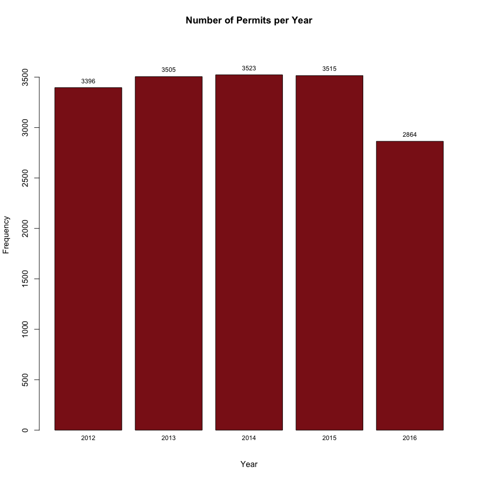

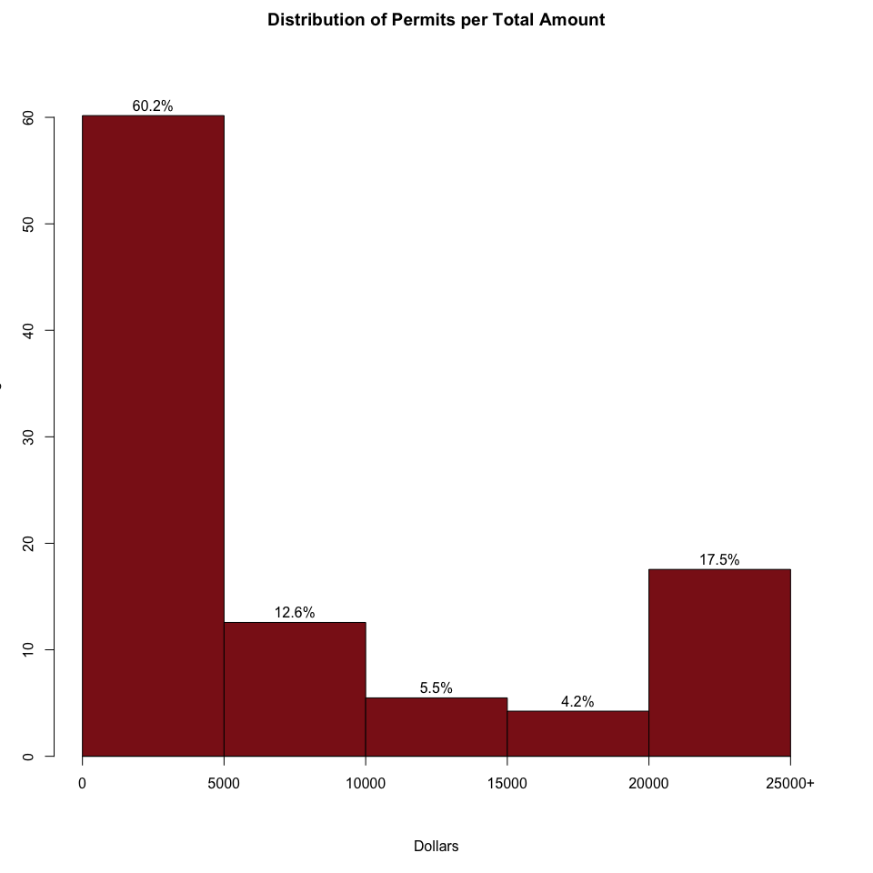

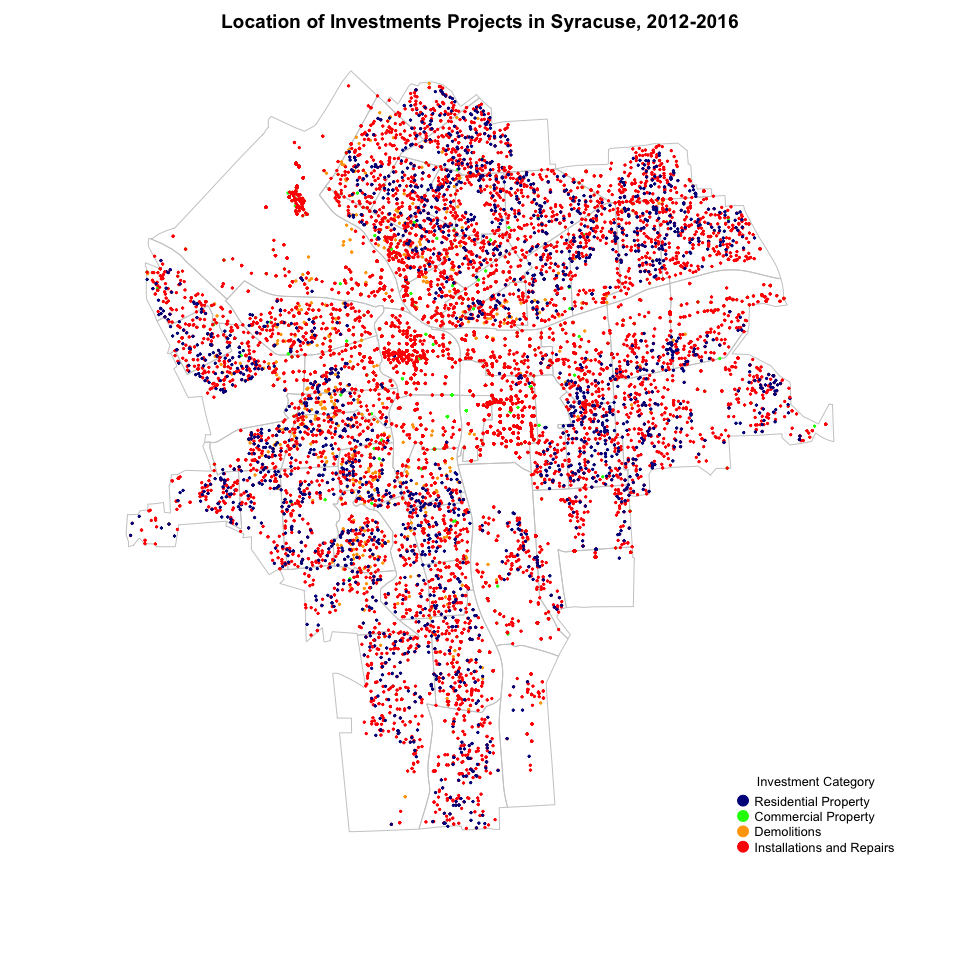

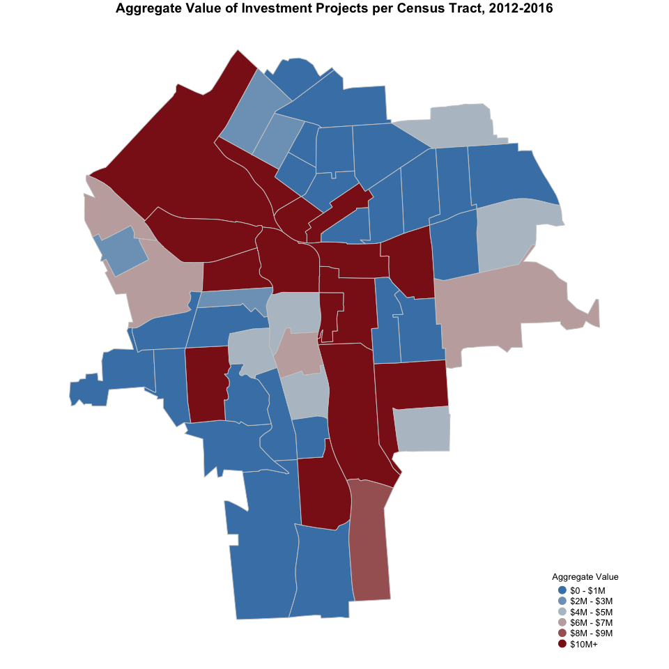

#### **2. Residential Property Investments**

#### Main takeaways:

- This category contains permits for new 1-2 family residential projects as well as remodeling and change in occupancy projects.
- There have been 2257 residential investment projects in the City of Syracuse over the last five years. Most of them are remodeling and change in occupancy projects (98%).
- The years 2014 and 2015 showed an important increase in the number of residential projects in, with a total of 565 and 598 projects, respectively. This figure dropped to 404 in 2016.
- Most residential investment projects (63.5%) have a value of $5,000 or below, while only 6.1% have a value of $20,000+.
- The census tracts around the South Valley, Far-West side, Westside, Near Northeast, Eastwood, Near Eastside, Westcott, University Neighborhood, Lincoln, Salt Springs, Sedgwick and Meadowbrook neighborhoods have received most residential investments projects, measured in aggregate value.

| Type | Observations | Min. | Median | Mean | Max. |
| --- | --- | --- | --- | --- | --- |
| Res. New 1-2 Family | 41 | 0 | 124000 | 122078.2 | 255539 |
| Res. Remodel/Chg Occ | 2216 | 0 | 3000 | 6955.0 | 360000 |

| Type | Observations | Min. | Median | Mean | Max. |
| --- | --- | --- | --- | --- | --- |
| All Residential Property | 2257 | 0 | 3000 | 9046.295 | 360000 |

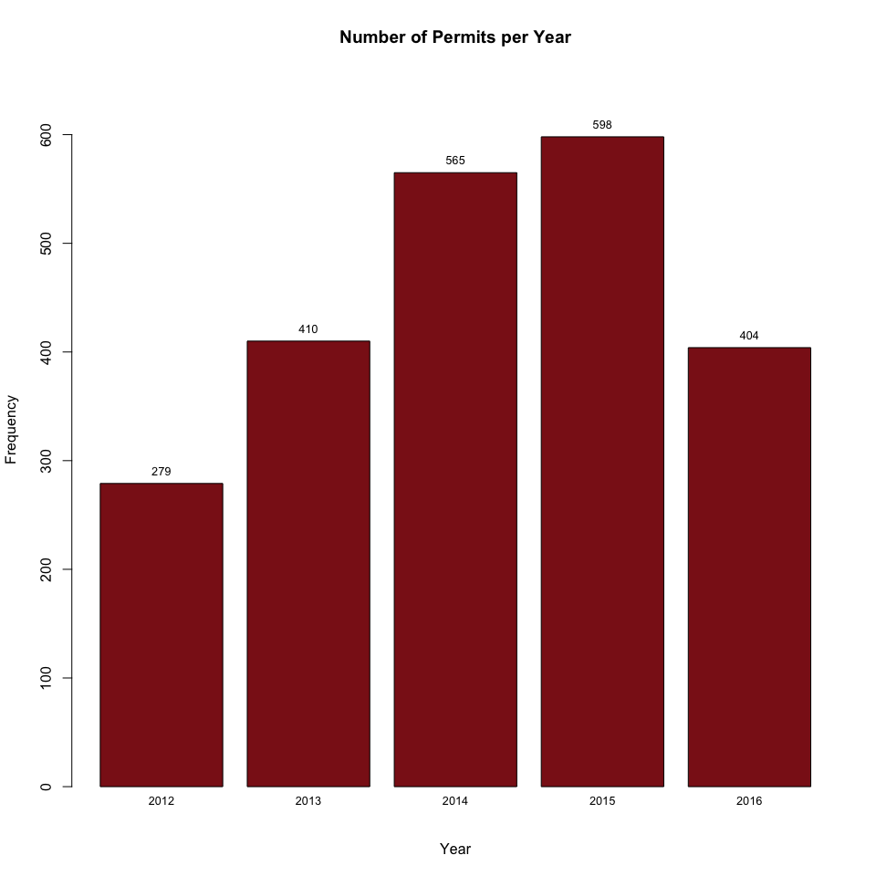

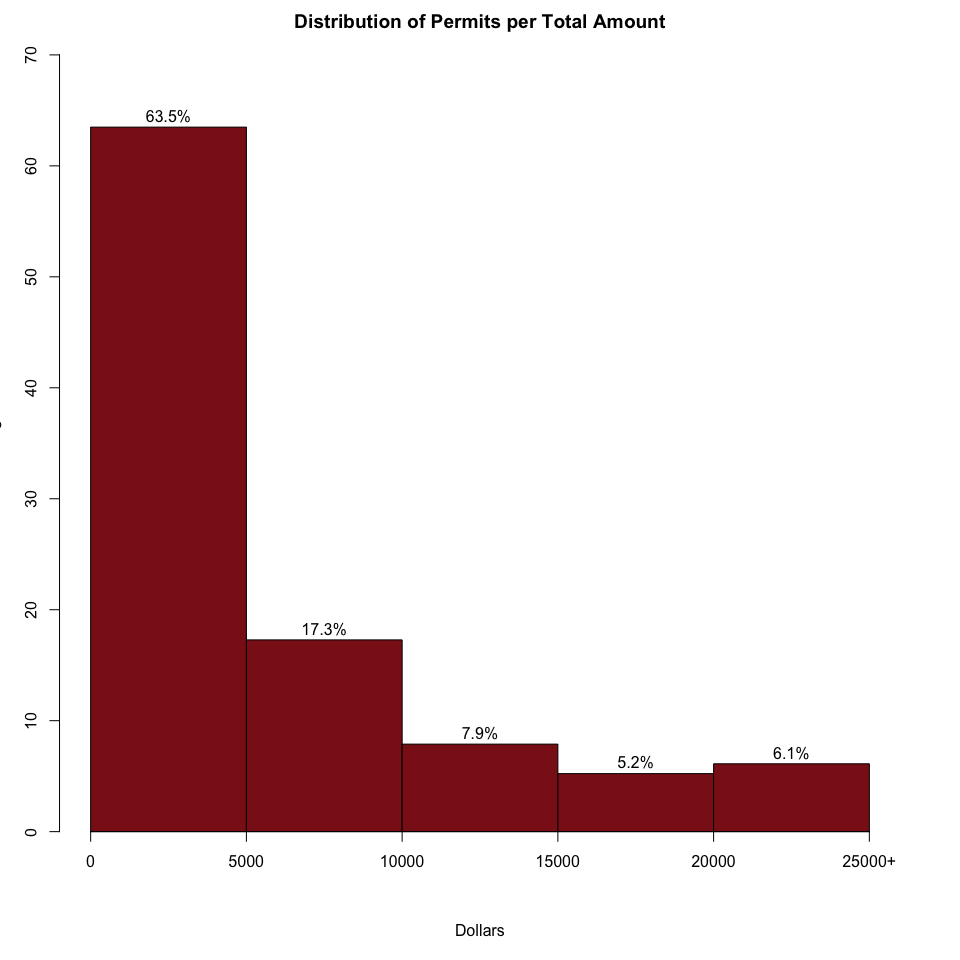

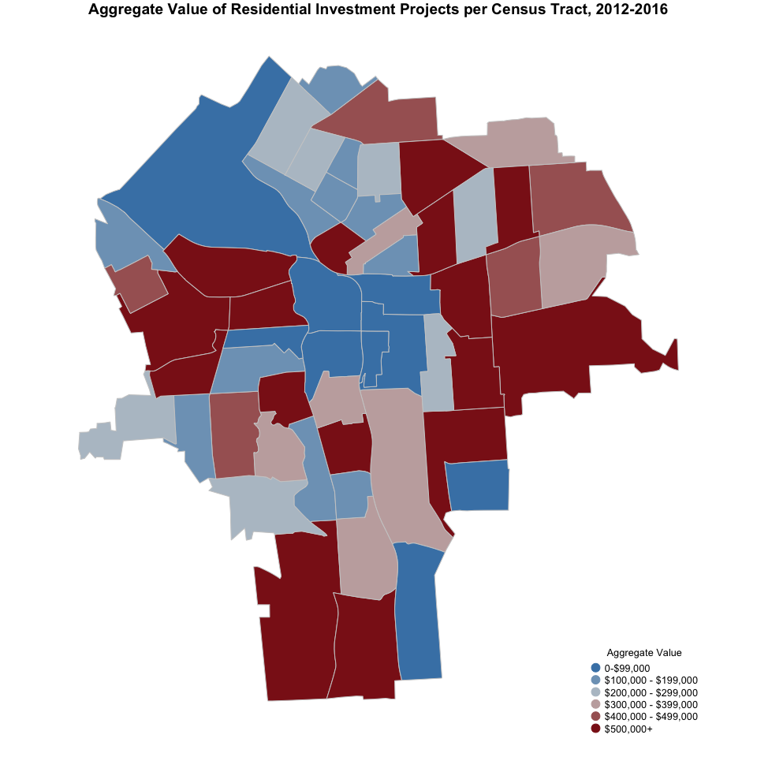

### **3. New/Reno of Commercial Property**

#### Main takeaways:

- This category contains permits for the construction of new commercial buildings as well as the renovation, remodeling or change in occupancy projects.
- There have been 1716 commercial investment projects over the last five years. Most of them have been renovation, remodeling or change in occupancy projects (96.7%).
- The number of commercial projects has been fairly consistent over the last five years, with an annual average of 342 permits per year.
- Most commercial investment projects (59.7%) had a value of $20,000+ and only 19.3% of projects had a value of $5,000 or below.
- Census tracts around Downtown, Lakefront, University Hill, Near Eastside, Highway 81 and Highway 690 have received most commercial investments projects, measured in aggregate value.

| Type | Observations | Min. | Median | Mean | Max. |
| --- | --- | --- | --- | --- | --- |
| Com. New Building | 56 | 1500 | 875000 | 2440788.8 | 15183229 |
| Com. Reno/Rem/Chg Occ | 1660 | 0 | 30000 | 247949.1 | 31811000 |

| Type | Observations | Min. | Median | Mean | Max. |
| --- | --- | --- | --- | --- | --- |
| All Commercial Property | 1716 | 0 | 34000 | 319510.3 | 31811000 |

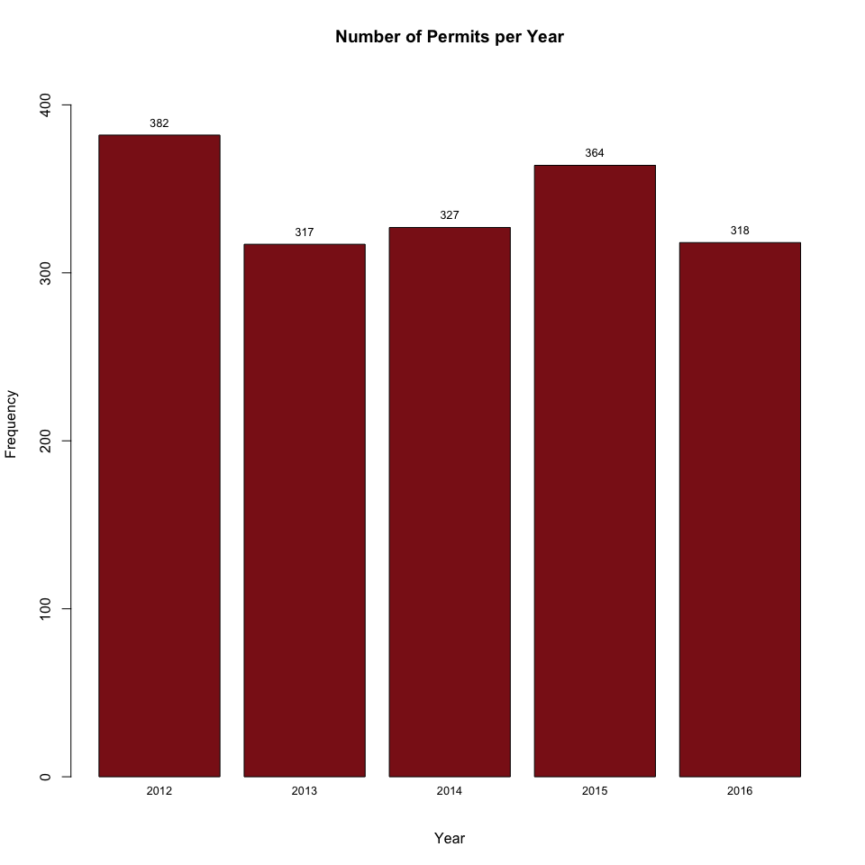

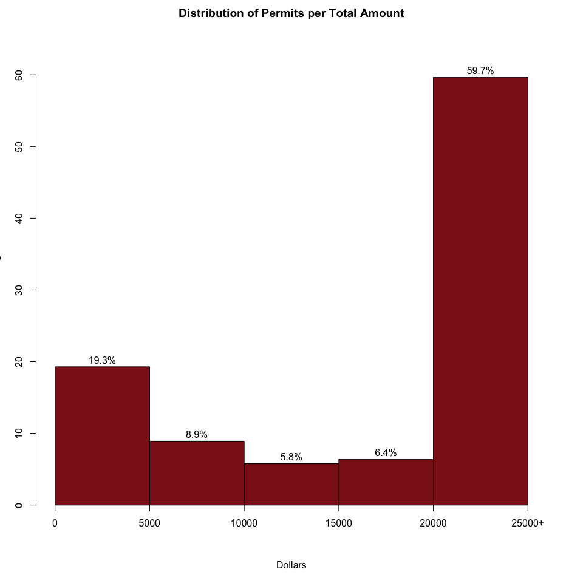

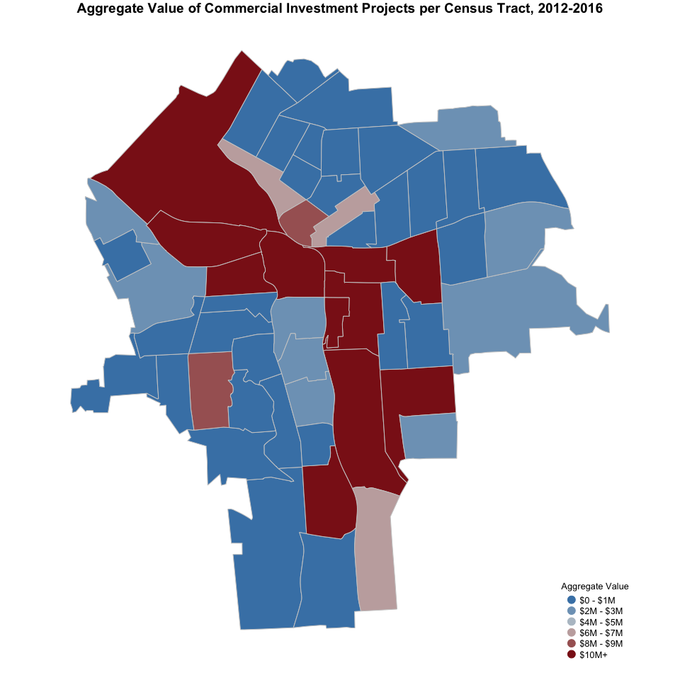

### **4. Demolitions**

| Type | Observations | Min. | Median | Mean | Max. |
| --- | --- | --- | --- | --- | --- |
| Demolitions | 595 | 0 | 11500 | 17511.1 | 3e+05 |

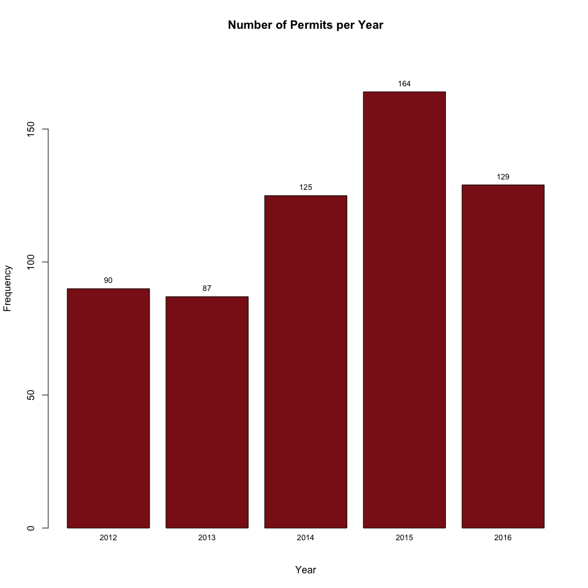

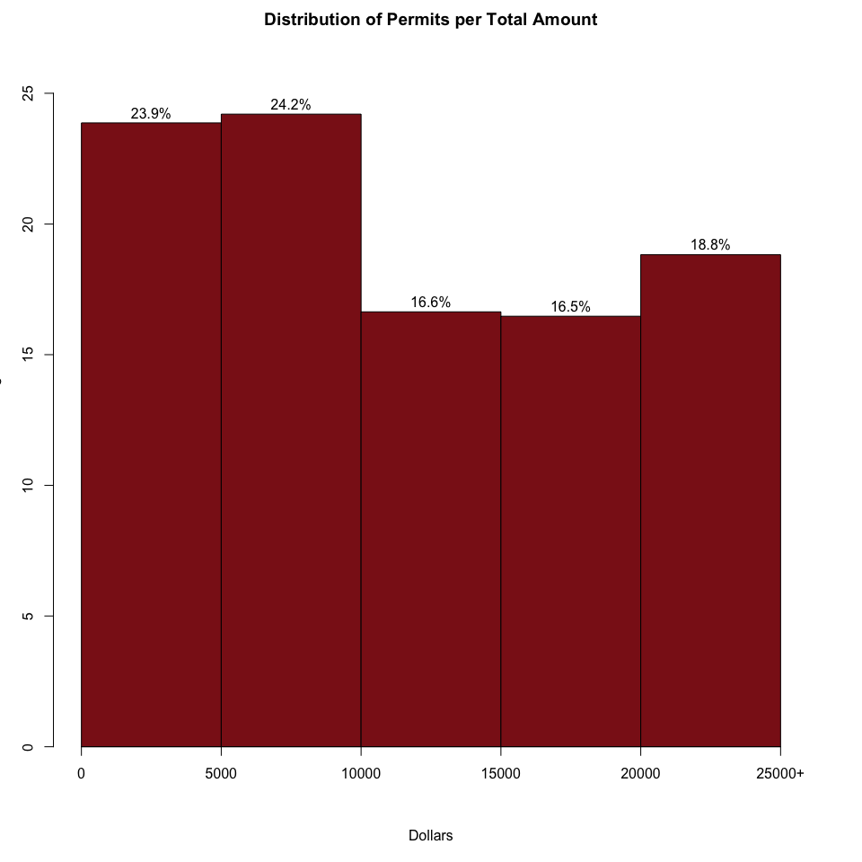

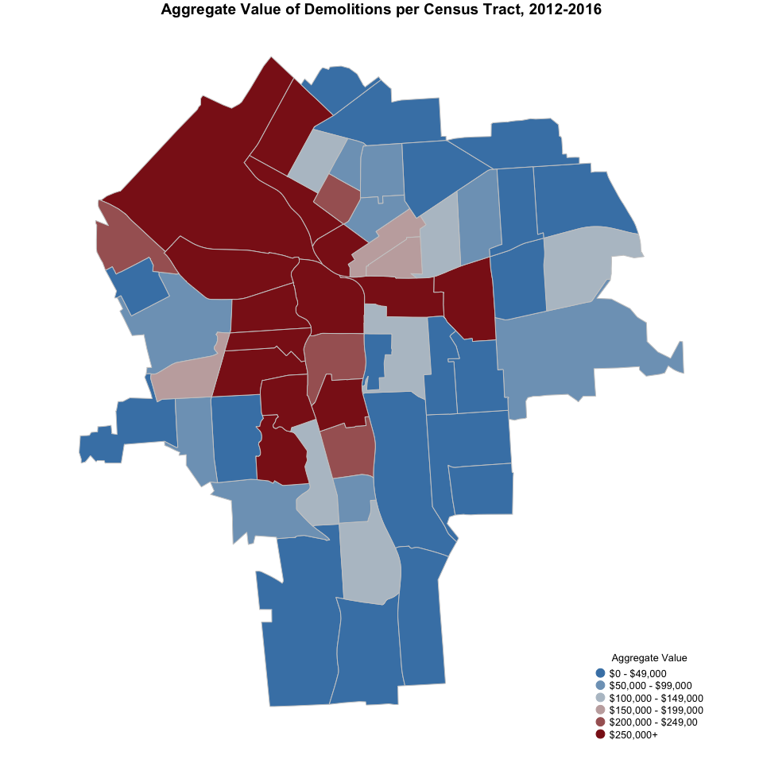

### **5. Installations and Repairs on all properties**

#### Main takeaways:

- This category is composed several kinds of permits, including: Electric, Elevator, Fire Alarm, HVAC/Mechanical, Misc.(deck, fence,ramp), Pool / Hot Tub, Security Alarm, Sprinkler, and Tank.
- There have been a total of 12,261 installations and repairs projects over the last five years. Most of them have been Electric (46.6%), HVAC/Mechanical (17.6%) and Sprinkler (14.5%) projects.
- The number of installations and repairs projects has been somewhat consistent over the last five years, with an annual average of 2,449 permits per year. However, last year, there was a small decrease in the number of installations and repairs permits with only 2,013.
- Most installations and repairs projects (67%) had a value of $5,000 or below and only and only 13.7% of projects had a value of $20,000+.
- The census tracts around Downtown, Lakefront, Westside, Near Eastside, Near Northeast, and Highway 81 have received most commercial investments projects, measured in aggregate value.

| Type | Observations | Min. | Median | Mean | Max. |
| --- | --- | --- | --- | --- | --- |
| Electric | 5712 | 0 | 2000 | 23317.348 | 8000000 |
| Elevator | 170 | 0 | 30650 | 73307.918 | 1172000 |
| Fire Alarm | 607 | 0 | 8960 | 52336.148 | 8000000 |
| HVAC/Mechanical | 2156 | 0 | 5650 | 52791.131 | 9764733 |
| Misc.(deck, fence,ramp) | 1159 | 0 | 2000 | 5166.703 | 2100000 |
| Pool / Hot Tub | 71 | 0 | 4000 | 6721.448 | 30000 |
| Security Alarm | 542 | 0 | 200 | 1215.267 | 91968 |
| Sprinkler | 1778 | 0 | 1650 | 10725.370 | 1396500 |
| Tank | 66 | 0 | 5000 | 17794.197 | 300000 |

| Type | Observations | Min. | Median | Mean | Max. |
| --- | --- | --- | --- | --- | --- |
| All Installations and Repairs | 12261 | 0 | 2600 | 25985.24 | 9764733 |

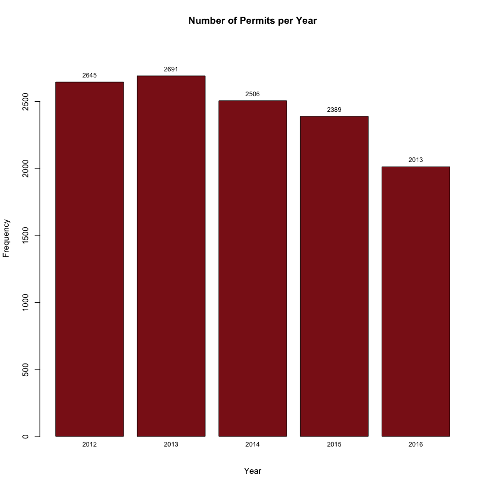

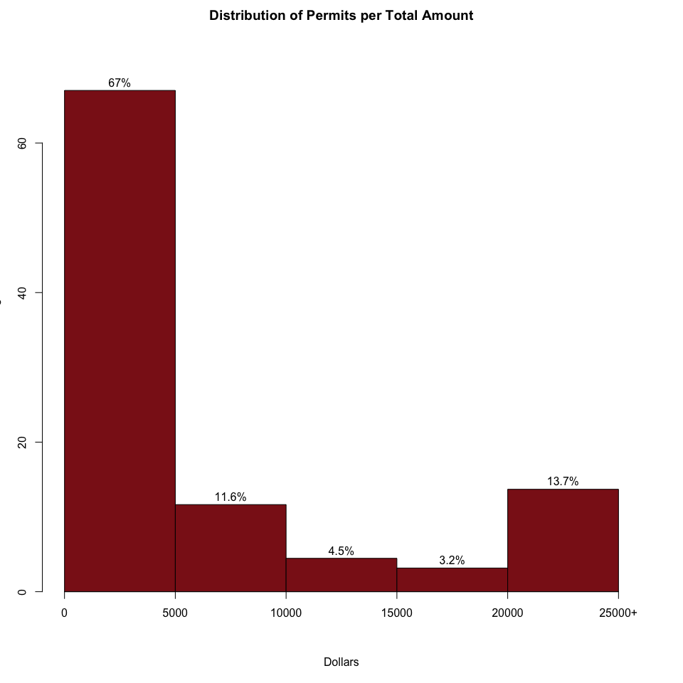

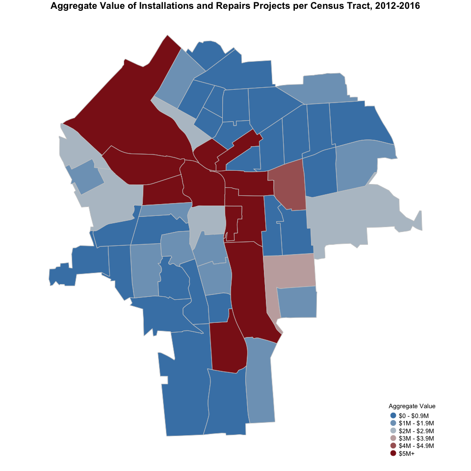